# Risk Factor Analysis

## Outcome Variable

**Outcome Variable:** pers_wasted624

## Predictor Variables

**Intervention Variable:** pers_wasted06

**Adjustment Set:**

unadjusted

## Stratifying Variables

The analysis was stratified on these variable(s):

- studyid
- country

## Data Summary

| studyid | country | pers_wasted06 | pers_wasted624 | n_cell | n |
| --- | --- | --- | --- | --- | --- |
| ki0047075b-MAL-ED | BANGLADESH | 0 | 0 | 218 | 239 |
| ki0047075b-MAL-ED | BANGLADESH | 0 | 1 | 15 | 239 |
| ki0047075b-MAL-ED | BANGLADESH | 1 | 0 | 3 | 239 |
| ki0047075b-MAL-ED | BANGLADESH | 1 | 1 | 3 | 239 |
| ki0047075b-MAL-ED | BRAZIL | 0 | 0 | 200 | 202 |
| ki0047075b-MAL-ED | BRAZIL | 0 | 1 | 1 | 202 |
| ki0047075b-MAL-ED | BRAZIL | 1 | 0 | 0 | 202 |
| ki0047075b-MAL-ED | BRAZIL | 1 | 1 | 1 | 202 |
| ki0047075b-MAL-ED | INDIA | 0 | 0 | 198 | 234 |
| ki0047075b-MAL-ED | INDIA | 0 | 1 | 18 | 234 |
| ki0047075b-MAL-ED | INDIA | 1 | 0 | 8 | 234 |
| ki0047075b-MAL-ED | INDIA | 1 | 1 | 10 | 234 |
| ki0047075b-MAL-ED | NEPAL | 0 | 0 | 229 | 234 |
| ki0047075b-MAL-ED | NEPAL | 0 | 1 | 1 | 234 |
| ki0047075b-MAL-ED | NEPAL | 1 | 0 | 3 | 234 |
| ki0047075b-MAL-ED | NEPAL | 1 | 1 | 1 | 234 |
| ki0047075b-MAL-ED | PERU | 0 | 0 | 262 | 264 |
| ki0047075b-MAL-ED | PERU | 0 | 1 | 2 | 264 |
| ki0047075b-MAL-ED | PERU | 1 | 0 | 0 | 264 |
| ki0047075b-MAL-ED | PERU | 1 | 1 | 0 | 264 |
| ki0047075b-MAL-ED | SOUTH AFRICA | 0 | 0 | 255 | 258 |
| ki0047075b-MAL-ED | SOUTH AFRICA | 0 | 1 | 1 | 258 |
| ki0047075b-MAL-ED | SOUTH AFRICA | 1 | 0 | 1 | 258 |
| ki0047075b-MAL-ED | SOUTH AFRICA | 1 | 1 | 1 | 258 |
| ki0047075b-MAL-ED | TANZANIA, UNITED REPUBLIC OF | 0 | 0 | 244 | 244 |
| ki0047075b-MAL-ED | TANZANIA, UNITED REPUBLIC OF | 0 | 1 | 0 | 244 |
| ki0047075b-MAL-ED | TANZANIA, UNITED REPUBLIC OF | 1 | 0 | 0 | 244 |
| ki0047075b-MAL-ED | TANZANIA, UNITED REPUBLIC OF | 1 | 1 | 0 | 244 |
| ki1000108-CMC-V-BCS-2002 | INDIA | 0 | 0 | 302 | 368 |
| ki1000108-CMC-V-BCS-2002 | INDIA | 0 | 1 | 12 | 368 |

[output cut: 118 more lines]

The following strata were considered:

- studyid: ki0047075b-MAL-ED, country: BANGLADESH
- studyid: ki0047075b-MAL-ED, country: BRAZIL
- studyid: ki0047075b-MAL-ED, country: INDIA
- studyid: ki0047075b-MAL-ED, country: NEPAL
- studyid: ki0047075b-MAL-ED, country: PERU
- studyid: ki0047075b-MAL-ED, country: SOUTH AFRICA
- studyid: ki0047075b-MAL-ED, country: TANZANIA, UNITED REPUBLIC OF
- studyid: ki1000108-CMC-V-BCS-2002, country: INDIA
- studyid: ki1000108-IRC, country: INDIA
- studyid: ki1000109-EE, country: PAKISTAN
- studyid: ki1000109-ResPak, country: PAKISTAN
- studyid: ki1000304-VITAMIN-A, country: INDIA
- studyid: ki1000304b-SAS-CompFeed, country: INDIA
- studyid: ki1000304b-SAS-FoodSuppl, country: INDIA
- studyid: ki1017093-NIH-Birth, country: BANGLADESH
- studyid: ki1017093b-PROVIDE, country: BANGLADESH
- studyid: ki1017093c-NIH-Crypto, country: BANGLADESH
- studyid: ki1066203-TanzaniaChild2, country: TANZANIA, UNITED REPUBLIC OF
- studyid: ki1101329-Keneba, country: GAMBIA
- studyid: ki1112895-Burkina Faso Zn, country: BURKINA FASO
- studyid: ki1112895-Guatemala BSC, country: GUATEMALA
- studyid: ki1113344-GMS-Nepal, country: NEPAL
- studyid: ki1114097-CMIN, country: BANGLADESH
- studyid: ki1114097-CMIN, country: BRAZIL
- studyid: ki1114097-CMIN, country: GUINEA-BISSAU
- studyid: ki1114097-CMIN, country: PERU
- studyid: ki1114097-CONTENT, country: PERU
- studyid: ki1119695-PROBIT, country: BELARUS
- studyid: ki1126311-ZVITAMBO, country: ZIMBABWE
- studyid: ki1135781-COHORTS, country: GUATEMALA
- studyid: ki1135781-COHORTS, country: INDIA
- studyid: ki1135781-COHORTS, country: PHILIPPINES
- studyid: ki1148112-iLiNS-DOSE, country: MALAWI
- studyid: ki1148112-iLiNS-DYAD-M, country: MALAWI
- studyid: ki1148112-LCNI-5, country: MALAWI
- studyid: kiGH5241-JiVitA-3, country: BANGLADESH
- studyid: kiGH5241-JiVitA-4, country: BANGLADESH

### Dropped Strata

Some strata were dropped due to rare outcomes:

- studyid: ki0047075b-MAL-ED, country: BANGLADESH
- studyid: ki0047075b-MAL-ED, country: BRAZIL
- studyid: ki0047075b-MAL-ED, country: NEPAL
- studyid: ki0047075b-MAL-ED, country: PERU
- studyid: ki0047075b-MAL-ED, country: SOUTH AFRICA
- studyid: ki0047075b-MAL-ED, country: TANZANIA, UNITED REPUBLIC OF
- studyid: ki1017093c-NIH-Crypto, country: BANGLADESH
- studyid: ki1112895-Burkina Faso Zn, country: BURKINA FASO
- studyid: ki1112895-Guatemala BSC, country: GUATEMALA
- studyid: ki1114097-CMIN, country: BANGLADESH
- studyid: ki1114097-CMIN, country: BRAZIL
- studyid: ki1114097-CMIN, country: PERU
- studyid: ki1114097-CONTENT, country: PERU
- studyid: ki1148112-iLiNS-DOSE, country: MALAWI
- studyid: ki1148112-iLiNS-DYAD-M, country: MALAWI
- studyid: ki1148112-LCNI-5, country: MALAWI

## Methods Detail

We’re interested in the causal parameters $E[Y_a]$ for all values of $a \in \mathcal{A}$. These parameters represent the mean outcome if, possibly contrary to fact, we intervened to set all units to have $A=a$. Under the randomization and positivity assumptions, these are identified by the statistical parameters $\psi_a=E_W[E_{Y|A,W}(Y|A=a,W)]$. In addition, we’re interested in the mean of $Y$, $E[Y]$ under no intervention (the observed mean). We will estimate these parameters by using SuperLearner to fit the relevant likelihood factors – $E_{Y|A,W}(Y|A=a,W)$ and $p(A=a|W)$, and then updating our likelihood fit using a joint TMLE.

For unadjusted analyses ($W=\{\}$), initial likelihoods were estimated using Lrnr_glm to estimate the simple $E(Y|A)$ and Lrnr_mean to estimate $p(A)$. For adjusted analyses, a small library containing Lrnr_glmnet, Lrnr_xgboost, and Lrnr_mean was used.

Having estimated these parameters, we will then use the delta method to estimate relative risks and attributable risks relative to a prespecified baseline level of $A$.

# Results Detail

## Results Plots

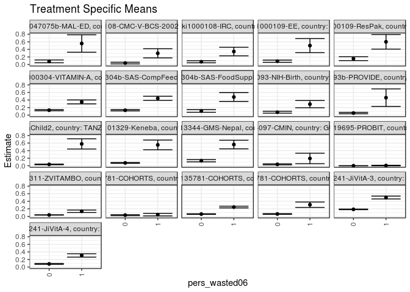

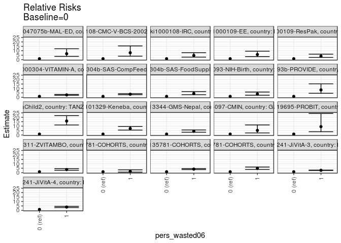

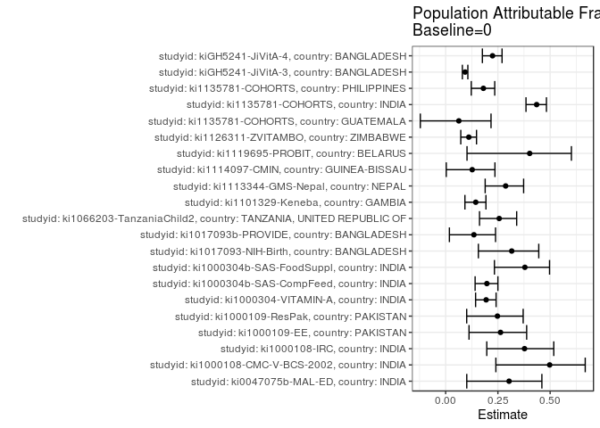

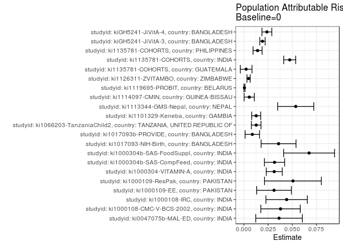

## Results Table

### Parameter: TSM

| studyid | country | intervention_level | baseline_level | estimate | ci_lower | ci_upper |
| --- | --- | --- | --- | --- | --- | --- |
| ki0047075b-MAL-ED | INDIA | 0 | NA | 0.0833333 | 0.0463959 | 0.1202707 |
| ki0047075b-MAL-ED | INDIA | 1 | NA | 0.5555556 | 0.3255098 | 0.7856013 |
| ki1000108-CMC-V-BCS-2002 | INDIA | 0 | NA | 0.0382166 | 0.0169822 | 0.0594509 |
| ki1000108-CMC-V-BCS-2002 | INDIA | 1 | NA | 0.2962963 | 0.1743412 | 0.4182514 |
| ki1000108-IRC | INDIA | 0 | NA | 0.0728863 | 0.0453427 | 0.1004299 |
| ki1000108-IRC | INDIA | 1 | NA | 0.3432836 | 0.2294537 | 0.4571135 |
| ki1000109-EE | PAKISTAN | 0 | NA | 0.0874636 | 0.0575253 | 0.1174018 |
| ki1000109-EE | PAKISTAN | 1 | NA | 0.5000000 | 0.3145507 | 0.6854493 |
| ki1000109-ResPak | PAKISTAN | 0 | NA | 0.1538462 | 0.1030901 | 0.2046022 |
| ki1000109-ResPak | PAKISTAN | 1 | NA | 0.6000000 | 0.4075256 | 0.7924744 |
| ki1000304-VITAMIN-A | INDIA | 0 | NA | 0.1303907 | 0.1155216 | 0.1452598 |
| ki1000304-VITAMIN-A | INDIA | 1 | NA | 0.3495441 | 0.2980088 | 0.4010793 |
| ki1000304b-SAS-CompFeed | INDIA | 0 | NA | 0.1287129 | 0.1116650 | 0.1457608 |
| ki1000304b-SAS-CompFeed | INDIA | 1 | NA | 0.4444444 | 0.3899011 | 0.4989878 |
| ki1000304b-SAS-FoodSuppl | INDIA | 0 | NA | 0.1104101 | 0.0758657 | 0.1449545 |
| ki1000304b-SAS-FoodSuppl | INDIA | 1 | NA | 0.4788732 | 0.3625246 | 0.5952219 |
| ki1017093-NIH-Birth | BANGLADESH | 0 | NA | 0.0774648 | 0.0520544 | 0.1028752 |
| ki1017093-NIH-Birth | BANGLADESH | 1 | NA | 0.2906977 | 0.1946339 | 0.3867615 |
| ki1017093b-PROVIDE | BANGLADESH | 0 | NA | 0.0554622 | 0.0369881 | 0.0739363 |
| ki1017093b-PROVIDE | BANGLADESH | 1 | NA | 0.4615385 | 0.2295775 | 0.6934994 |
| ki1066203-TanzaniaChild2 | TANZANIA, UNITED REPUBLIC OF | 0 | NA | 0.0367804 | 0.0282471 | 0.0453137 |
| ki1066203-TanzaniaChild2 | TANZANIA, UNITED REPUBLIC OF | 1 | NA | 0.5777778 | 0.4425235 | 0.7130321 |
| ki1101329-Keneba | GAMBIA | 0 | NA | 0.0752587 | 0.0640423 | 0.0864751 |
| ki1101329-Keneba | GAMBIA | 1 | NA | 0.5517241 | 0.4237073 | 0.6797410 |
| ki1113344-GMS-Nepal | NEPAL | 0 | NA | 0.1330724 | 0.1035980 | 0.1625468 |
| ki1113344-GMS-Nepal | NEPAL | 1 | NA | 0.5616438 | 0.4477231 | 0.6755646 |
| ki1114097-CMIN | GUINEA-BISSAU | 0 | NA | 0.0377358 | 0.0249030 | 0.0505687 |
| ki1114097-CMIN | GUINEA-BISSAU | 1 | NA | 0.1935484 | 0.0543935 | 0.3327032 |
| ki1119695-PROBIT | BELARUS | 0 | NA | 0.0007270 | 0.0001693 | 0.0012847 |
| ki1119695-PROBIT | BELARUS | 1 | NA | 0.0068285 | -0.0005804 | 0.0142374 |
| ki1126311-ZVITAMBO | ZIMBABWE | 0 | NA | 0.0384235 | 0.0342358 | 0.0426113 |
| ki1126311-ZVITAMBO | ZIMBABWE | 1 | NA | 0.1350711 | 0.1024582 | 0.1676839 |
| ki1135781-COHORTS | GUATEMALA | 0 | NA | 0.0334225 | 0.0205347 | 0.0463102 |
| ki1135781-COHORTS | GUATEMALA | 1 | NA | 0.0469799 | 0.0129857 | 0.0809740 |
| ki1135781-COHORTS | INDIA | 0 | NA | 0.0614015 | 0.0542922 | 0.0685108 |
| ki1135781-COHORTS | INDIA | 1 | NA | 0.2468397 | 0.2250396 | 0.2686397 |
| ki1135781-COHORTS | PHILIPPINES | 0 | NA | 0.0639199 | 0.0545104 | 0.0733294 |
| ki1135781-COHORTS | PHILIPPINES | 1 | NA | 0.3081761 | 0.2363924 | 0.3799598 |
| kiGH5241-JiVitA-3 | BANGLADESH | 0 | NA | 0.1864889 | 0.1790745 | 0.1939033 |
| kiGH5241-JiVitA-3 | BANGLADESH | 1 | NA | 0.4994259 | 0.4616389 | 0.5372130 |
| kiGH5241-JiVitA-4 | BANGLADESH | 0 | NA | 0.0821278 | 0.0715990 | 0.0926565 |
| kiGH5241-JiVitA-4 | BANGLADESH | 1 | NA | 0.3063910 | 0.2624801 | 0.3503019 |

### Parameter: E(Y)

| studyid | country | intervention_level | baseline_level | estimate | ci_lower | ci_upper |
| --- | --- | --- | --- | --- | --- | --- |
| ki0047075b-MAL-ED | INDIA | NA | NA | 0.1196581 | 0.0779840 | 0.1613323 |
| ki1000108-CMC-V-BCS-2002 | INDIA | NA | NA | 0.0760870 | 0.0489610 | 0.1032130 |
| ki1000108-IRC | INDIA | NA | NA | 0.1170732 | 0.0859146 | 0.1482317 |
| ki1000109-EE | PAKISTAN | NA | NA | 0.1185984 | 0.0856546 | 0.1515422 |
| ki1000109-ResPak | PAKISTAN | NA | NA | 0.2045455 | 0.1511224 | 0.2579685 |
| ki1000304-VITAMIN-A | INDIA | NA | NA | 0.1617391 | 0.1466878 | 0.1767905 |
| ki1000304b-SAS-CompFeed | INDIA | NA | NA | 0.1603563 | 0.1395035 | 0.1812092 |
| ki1000304b-SAS-FoodSuppl | INDIA | NA | NA | 0.1778351 | 0.1397389 | 0.2159312 |
| ki1017093-NIH-Birth | BANGLADESH | NA | NA | 0.1132813 | 0.0858017 | 0.1407608 |
| ki1017093b-PROVIDE | BANGLADESH | NA | NA | 0.0641447 | 0.0446535 | 0.0836359 |
| ki1066203-TanzaniaChild2 | TANZANIA, UNITED REPUBLIC OF | NA | NA | 0.0494534 | 0.0397554 | 0.0591514 |
| ki1101329-Keneba | GAMBIA | NA | NA | 0.0879121 | 0.0760335 | 0.0997906 |
| ki1113344-GMS-Nepal | NEPAL | NA | NA | 0.1866438 | 0.1550166 | 0.2182711 |
| ki1114097-CMIN | GUINEA-BISSAU | NA | NA | 0.0432309 | 0.0297785 | 0.0566834 |
| ki1119695-PROBIT | BELARUS | NA | NA | 0.0012159 | 0.0002433 | 0.0021885 |
| ki1126311-ZVITAMBO | ZIMBABWE | NA | NA | 0.0432128 | 0.0388939 | 0.0475316 |
| ki1135781-COHORTS | GUATEMALA | NA | NA | 0.0356745 | 0.0235298 | 0.0478191 |
| ki1135781-COHORTS | INDIA | NA | NA | 0.1087695 | 0.1008135 | 0.1167256 |
| ki1135781-COHORTS | PHILIPPINES | NA | NA | 0.0780116 | 0.0679971 | 0.0880261 |
| kiGH5241-JiVitA-3 | BANGLADESH | NA | NA | 0.2056528 | 0.1980793 | 0.2132263 |
| kiGH5241-JiVitA-4 | BANGLADESH | NA | NA | 0.1058706 | 0.0951082 | 0.1166330 |

### Parameter: RR

| studyid | country | intervention_level | baseline_level | estimate | ci_lower | ci_upper |
| --- | --- | --- | --- | --- | --- | --- |
| ki0047075b-MAL-ED | INDIA | 0 | 0 | 1.000000 | 1.0000000 | 1.000000 |
| ki0047075b-MAL-ED | INDIA | 1 | 0 | 6.666667 | 3.6347655 | 12.227596 |
| ki1000108-CMC-V-BCS-2002 | INDIA | 0 | 0 | 1.000000 | 1.0000000 | 1.000000 |
| ki1000108-CMC-V-BCS-2002 | INDIA | 1 | 0 | 7.753086 | 3.8830245 | 15.480291 |
| ki1000108-IRC | INDIA | 0 | 0 | 1.000000 | 1.0000000 | 1.000000 |
| ki1000108-IRC | INDIA | 1 | 0 | 4.709851 | 2.8488169 | 7.786634 |
| ki1000109-EE | PAKISTAN | 0 | 0 | 1.000000 | 1.0000000 | 1.000000 |
| ki1000109-EE | PAKISTAN | 1 | 0 | 5.716667 | 3.4510463 | 9.469672 |
| ki1000109-ResPak | PAKISTAN | 0 | 0 | 1.000000 | 1.0000000 | 1.000000 |
| ki1000109-ResPak | PAKISTAN | 1 | 0 | 3.900000 | 2.4616043 | 6.178897 |
| ki1000304-VITAMIN-A | INDIA | 0 | 0 | 1.000000 | 1.0000000 | 1.000000 |
| ki1000304-VITAMIN-A | INDIA | 1 | 0 | 2.680745 | 2.2248835 | 3.230008 |
| ki1000304b-SAS-CompFeed | INDIA | 0 | 0 | 1.000000 | 1.0000000 | 1.000000 |
| ki1000304b-SAS-CompFeed | INDIA | 1 | 0 | 3.452991 | 2.9127890 | 4.093379 |
| ki1000304b-SAS-FoodSuppl | INDIA | 0 | 0 | 1.000000 | 1.0000000 | 1.000000 |
| ki1000304b-SAS-FoodSuppl | INDIA | 1 | 0 | 4.337223 | 2.9185925 | 6.445404 |
| ki1017093-NIH-Birth | BANGLADESH | 0 | 0 | 1.000000 | 1.0000000 | 1.000000 |
| ki1017093-NIH-Birth | BANGLADESH | 1 | 0 | 3.752643 | 2.3557005 | 5.977979 |
| ki1017093b-PROVIDE | BANGLADESH | 0 | 0 | 1.000000 | 1.0000000 | 1.000000 |
| ki1017093b-PROVIDE | BANGLADESH | 1 | 0 | 8.321678 | 4.5536120 | 15.207780 |
| ki1066203-TanzaniaChild2 | TANZANIA, UNITED REPUBLIC OF | 0 | 0 | 1.000000 | 1.0000000 | 1.000000 |
| ki1066203-TanzaniaChild2 | TANZANIA, UNITED REPUBLIC OF | 1 | 0 | 15.708857 | 11.2981455 | 21.841476 |
| ki1101329-Keneba | GAMBIA | 0 | 0 | 1.000000 | 1.0000000 | 1.000000 |
| ki1101329-Keneba | GAMBIA | 1 | 0 | 7.331035 | 5.5641483 | 9.658992 |
| ki1113344-GMS-Nepal | NEPAL | 0 | 0 | 1.000000 | 1.0000000 | 1.000000 |
| ki1113344-GMS-Nepal | NEPAL | 1 | 0 | 4.220588 | 3.1256453 | 5.699100 |
| ki1114097-CMIN | GUINEA-BISSAU | 0 | 0 | 1.000000 | 1.0000000 | 1.000000 |
| ki1114097-CMIN | GUINEA-BISSAU | 1 | 0 | 5.129032 | 2.3153952 | 11.361763 |
| ki1119695-PROBIT | BELARUS | 0 | 0 | 1.000000 | 1.0000000 | 1.000000 |
| ki1119695-PROBIT | BELARUS | 1 | 0 | 9.392951 | 3.6435746 | 24.214551 |
| ki1126311-ZVITAMBO | ZIMBABWE | 0 | 0 | 1.000000 | 1.0000000 | 1.000000 |
| ki1126311-ZVITAMBO | ZIMBABWE | 1 | 0 | 3.515323 | 2.6972228 | 4.581562 |
| ki1135781-COHORTS | GUATEMALA | 0 | 0 | 1.000000 | 1.0000000 | 1.000000 |
| ki1135781-COHORTS | GUATEMALA | 1 | 0 | 1.405638 | 0.6191362 | 3.191248 |
| ki1135781-COHORTS | INDIA | 0 | 0 | 1.000000 | 1.0000000 | 1.000000 |
| ki1135781-COHORTS | INDIA | 1 | 0 | 4.020091 | 3.4753064 | 4.650276 |
| ki1135781-COHORTS | PHILIPPINES | 0 | 0 | 1.000000 | 1.0000000 | 1.000000 |
| ki1135781-COHORTS | PHILIPPINES | 1 | 0 | 4.821285 | 3.6601077 | 6.350849 |
| kiGH5241-JiVitA-3 | BANGLADESH | 0 | 0 | 1.000000 | 1.0000000 | 1.000000 |
| kiGH5241-JiVitA-3 | BANGLADESH | 1 | 0 | 2.678046 | 2.4639677 | 2.910725 |
| kiGH5241-JiVitA-4 | BANGLADESH | 0 | 0 | 1.000000 | 1.0000000 | 1.000000 |
| kiGH5241-JiVitA-4 | BANGLADESH | 1 | 0 | 3.730663 | 3.0878604 | 4.507278 |

### Parameter: PAR

| studyid | country | intervention_level | baseline_level | estimate | ci_lower | ci_upper |
| --- | --- | --- | --- | --- | --- | --- |
| ki0047075b-MAL-ED | INDIA | 0 | NA | 0.0363248 | 0.0121946 | 0.0604550 |
| ki1000108-CMC-V-BCS-2002 | INDIA | 0 | NA | 0.0378704 | 0.0174437 | 0.0582971 |
| ki1000108-IRC | INDIA | 0 | NA | 0.0441869 | 0.0227356 | 0.0656381 |
| ki1000109-EE | PAKISTAN | 0 | NA | 0.0311348 | 0.0131269 | 0.0491428 |
| ki1000109-ResPak | PAKISTAN | 0 | NA | 0.0506993 | 0.0213167 | 0.0800819 |
| ki1000304-VITAMIN-A | INDIA | 0 | NA | 0.0313485 | 0.0230597 | 0.0396373 |
| ki1000304b-SAS-CompFeed | INDIA | 0 | NA | 0.0316435 | 0.0211810 | 0.0421059 |
| ki1000304b-SAS-FoodSuppl | INDIA | 0 | NA | 0.0674250 | 0.0410673 | 0.0937826 |
| ki1017093-NIH-Birth | BANGLADESH | 0 | NA | 0.0358165 | 0.0177514 | 0.0538816 |
| ki1017093b-PROVIDE | BANGLADESH | 0 | NA | 0.0086826 | 0.0012208 | 0.0161443 |
| ki1066203-TanzaniaChild2 | TANZANIA, UNITED REPUBLIC OF | 0 | NA | 0.0126730 | 0.0076855 | 0.0176605 |
| ki1101329-Keneba | GAMBIA | 0 | NA | 0.0126534 | 0.0079657 | 0.0173411 |
| ki1113344-GMS-Nepal | NEPAL | 0 | NA | 0.0535714 | 0.0348972 | 0.0722456 |
| ki1114097-CMIN | GUINEA-BISSAU | 0 | NA | 0.0054951 | 0.0002127 | 0.0107775 |
| ki1119695-PROBIT | BELARUS | 0 | NA | 0.0004889 | -0.0000743 | 0.0010521 |
| ki1126311-ZVITAMBO | ZIMBABWE | 0 | NA | 0.0047893 | 0.0031001 | 0.0064784 |
| ki1135781-COHORTS | GUATEMALA | 0 | NA | 0.0022520 | -0.0037959 | 0.0083000 |
| ki1135781-COHORTS | INDIA | 0 | NA | 0.0473680 | 0.0411570 | 0.0535791 |
| ki1135781-COHORTS | PHILIPPINES | 0 | NA | 0.0140917 | 0.0094047 | 0.0187787 |
| kiGH5241-JiVitA-3 | BANGLADESH | 0 | NA | 0.0191639 | 0.0163842 | 0.0219436 |
| kiGH5241-JiVitA-4 | BANGLADESH | 0 | NA | 0.0237429 | 0.0186562 | 0.0288295 |

### Parameter: PAF

| studyid | country | intervention_level | baseline_level | estimate | ci_lower | ci_upper |
| --- | --- | --- | --- | --- | --- | --- |
| ki0047075b-MAL-ED | INDIA | 0 | NA | 0.3035714 | 0.1010431 | 0.4604716 |
| ki1000108-CMC-V-BCS-2002 | INDIA | 0 | NA | 0.4977252 | 0.2403050 | 0.6679194 |
| ki1000108-IRC | INDIA | 0 | NA | 0.3774295 | 0.1968198 | 0.5174259 |
| ki1000109-EE | PAKISTAN | 0 | NA | 0.2625232 | 0.1118665 | 0.3876235 |
| ki1000109-ResPak | PAKISTAN | 0 | NA | 0.2478632 | 0.1006993 | 0.3709449 |
| ki1000304-VITAMIN-A | INDIA | 0 | NA | 0.1938212 | 0.1432880 | 0.2413737 |
| ki1000304b-SAS-CompFeed | INDIA | 0 | NA | 0.1973322 | 0.1409545 | 0.2500100 |
| ki1000304b-SAS-FoodSuppl | INDIA | 0 | NA | 0.3791432 | 0.2333849 | 0.4971882 |
| ki1017093-NIH-Birth | BANGLADESH | 0 | NA | 0.3161729 | 0.1565731 | 0.4455720 |
| ki1017093b-PROVIDE | BANGLADESH | 0 | NA | 0.1353588 | 0.0179429 | 0.2387362 |
| ki1066203-TanzaniaChild2 | TANZANIA, UNITED REPUBLIC OF | 0 | NA | 0.2562619 | 0.1620719 | 0.3398642 |
| ki1101329-Keneba | GAMBIA | 0 | NA | 0.1439323 | 0.0921530 | 0.1927583 |
| ki1113344-GMS-Nepal | NEPAL | 0 | NA | 0.2870249 | 0.1891040 | 0.3731212 |
| ki1114097-CMIN | GUINEA-BISSAU | 0 | NA | 0.1271102 | 0.0028857 | 0.2358584 |
| ki1119695-PROBIT | BELARUS | 0 | NA | 0.4020917 | 0.1022350 | 0.6017952 |
| ki1126311-ZVITAMBO | ZIMBABWE | 0 | NA | 0.1108295 | 0.0724040 | 0.1476634 |
| ki1135781-COHORTS | GUATEMALA | 0 | NA | 0.0631267 | -0.1211887 | 0.2171419 |
| ki1135781-COHORTS | INDIA | 0 | NA | 0.4354899 | 0.3844691 | 0.4822816 |
| ki1135781-COHORTS | PHILIPPINES | 0 | NA | 0.1806360 | 0.1225770 | 0.2348532 |
| kiGH5241-JiVitA-3 | BANGLADESH | 0 | NA | 0.0931857 | 0.0799683 | 0.1062132 |
| kiGH5241-JiVitA-4 | BANGLADESH | 0 | NA | 0.2242632 | 0.1757884 | 0.2698871 |